# FinalResults_01-DataProcessing

Predicting Online News Popularity based on Pre-publication Features

Final Results and Code

Link to dataset: https://archive.ics.uci.edu/ml/datasets/Online+News+Popularity

Link to data: https://archive.ics.uci.edu/ml/machine-learning-databases/00332/OnlineNewsPopularity.zip

Step 1 - Data Processing

The “Online News Popularity Data Set” (Fernandes et al., 2015) is retrieved from the UCI Machine Learning Repository, and data processing procedures are implemented. At the start of the univariate analysis, the target variable is determined to be the number of shares; and articles are classified as popular or unpopular based on the number of shares. Various graphs are plotted such as boxplots and histograms to detect outliers, illustrate whether the data is normally distributed, and whether the data is balanced. To determine whether there are any variables with low variance, a near-zero variance filter is used to filter out the attributes with near-zero variance and help to reduce the dimensionality of the dataset. In bivariate analysis, pairwise relations are examined between the input variables as well as the output and input variables. Scatterplots provide visualisations to better understand the data; and correlation analysis is done to help reduce the dimensionality of the dataset when there is high correlation among the independent variables.

Initial Analysis - Univariate Analysis

```r
#Read the data
temp <- tempfile()
download.file("https://archive.ics.uci.edu/ml/machine-learning-databases/00332/OnlineNewsPopularity.zip",temp)
pop <- read.table(unz(temp, "OnlineNewsPopularity/OnlineNewsPopularity.csv"), header = TRUE, sep = ",",
                  stringsAsFactors = FALSE, na.strings = c("", "NA"))
unlink(temp)
```

```r
#View the first few rows of the dataset
head(pop)
```

```
##                                                              url timedelta
## 1   http://mashable.com/2013/01/07/amazon-instant-video-browser/       731
## 2    http://mashable.com/2013/01/07/ap-samsung-sponsored-tweets/       731
## 3 http://mashable.com/2013/01/07/apple-40-billion-app-downloads/       731
## 4       http://mashable.com/2013/01/07/astronaut-notre-dame-bcs/       731
## 5               http://mashable.com/2013/01/07/att-u-verse-apps/       731
## 6               http://mashable.com/2013/01/07/beewi-smart-toys/       731
##   n_tokens_title n_tokens_content n_unique_tokens n_non_stop_words
## 1             12              219       0.6635945                1
## 2              9              255       0.6047431                1
## 3              9              211       0.5751295                1
## 4              9              531       0.5037879                1
## 5             13             1072       0.4156456                1
## 6             10              370       0.5598886                1
##   n_non_stop_unique_tokens num_hrefs num_self_hrefs num_imgs num_videos
```

[output cut: 111 more lines]

```r
#View the last few rows of the dataset
tail(pop)
```

```
##                                                                                         url
## 39639                       http://mashable.com/2014/12/27/protests-continue-ramos-funeral/
## 39640                                    http://mashable.com/2014/12/27/samsung-app-autism/
## 39641 http://mashable.com/2014/12/27/seth-rogen-james-franco-will-live-tweet-the-interview/
## 39642                                 http://mashable.com/2014/12/27/son-pays-off-mortgage/
## 39643                                        http://mashable.com/2014/12/27/ukraine-blasts/
## 39644                                 http://mashable.com/2014/12/27/youtube-channels-2015/
##       timedelta n_tokens_title n_tokens_content n_unique_tokens
## 39639         8             11              223       0.6531532
## 39640         8             11              346       0.5290520
## 39641         8             12              328       0.6962963
## 39642         8             10              442       0.5163551
## 39643         8              6              682       0.5394933
## 39644         8             10              157       0.7019868
##       n_non_stop_words n_non_stop_unique_tokens num_hrefs num_self_hrefs
```

[output cut: 118 more lines]

```r
#Number of rows
nrow(pop)
```

```
## [1] 39644
```

```r
#Number of attributes
length(pop)
```

```
## [1] 61
```

```r
#Data type of attributes
sapply(pop, class)
```

```
##                           url                     timedelta
##                   "character"                     "numeric"
##                n_tokens_title              n_tokens_content
##                     "numeric"                     "numeric"
##               n_unique_tokens              n_non_stop_words
##                     "numeric"                     "numeric"
##      n_non_stop_unique_tokens                     num_hrefs
##                     "numeric"                     "numeric"
##                num_self_hrefs                      num_imgs
##                     "numeric"                     "numeric"
##                    num_videos          average_token_length
##                     "numeric"                     "numeric"
##                  num_keywords     data_channel_is_lifestyle
##                     "numeric"                     "numeric"
## data_channel_is_entertainment           data_channel_is_bus
##                     "numeric"                     "numeric"
##        data_channel_is_socmed          data_channel_is_tech
##                     "numeric"                     "numeric"
##         data_channel_is_world                    kw_min_min
##                     "numeric"                     "numeric"
##                    kw_max_min                    kw_avg_min
##                     "numeric"                     "numeric"
##                    kw_min_max                    kw_max_max
##                     "numeric"                     "numeric"
##                    kw_avg_max                    kw_min_avg
##                     "numeric"                     "numeric"
##                    kw_max_avg                    kw_avg_avg
##                     "numeric"                     "numeric"
##     self_reference_min_shares     self_reference_max_shares
##                     "numeric"                     "numeric"
##    self_reference_avg_sharess             weekday_is_monday
##                     "numeric"                     "numeric"
##            weekday_is_tuesday          weekday_is_wednesday
##                     "numeric"                     "numeric"
##           weekday_is_thursday             weekday_is_friday
##                     "numeric"                     "numeric"
##           weekday_is_saturday             weekday_is_sunday
##                     "numeric"                     "numeric"
##                    is_weekend                        LDA_00
##                     "numeric"                     "numeric"
##                        LDA_01                        LDA_02
##                     "numeric"                     "numeric"
##                        LDA_03                        LDA_04
##                     "numeric"                     "numeric"
##           global_subjectivity     global_sentiment_polarity
##                     "numeric"                     "numeric"
##    global_rate_positive_words    global_rate_negative_words
##                     "numeric"                     "numeric"
##           rate_positive_words           rate_negative_words
##                     "numeric"                     "numeric"
##         avg_positive_polarity         min_positive_polarity
##                     "numeric"                     "numeric"
##         max_positive_polarity         avg_negative_polarity
##                     "numeric"                     "numeric"
##         min_negative_polarity         max_negative_polarity
##                     "numeric"                     "numeric"
##            title_subjectivity      title_sentiment_polarity
##                     "numeric"                     "numeric"
##        abs_title_subjectivity  abs_title_sentiment_polarity
##                     "numeric"                     "numeric"
##                        shares
##                     "integer"
```

The “shares” column is of type integer, “url” is of type character, and the remainder of the variables are of type numeric.

```r
#Structure of the dataset
str(pop)
```

```
## 'data.frame':    39644 obs. of  61 variables:
##  $ url                          : chr  "http://mashable.com/2013/01/07/amazon-instant-video-browser/" "http://mashable.com/2013/01/07/ap-samsung-sponsored-tweets/" "http://mashable.com/2013/01/07/apple-40-billion-app-downloads/" "http://mashable.com/2013/01/07/astronaut-notre-dame-bcs/" ...
##  $ timedelta                    : num  731 731 731 731 731 731 731 731 731 731 ...
##  $ n_tokens_title               : num  12 9 9 9 13 10 8 12 11 10 ...
##  $ n_tokens_content             : num  219 255 211 531 1072 ...
##  $ n_unique_tokens              : num  0.664 0.605 0.575 0.504 0.416 ...
##  $ n_non_stop_words             : num  1 1 1 1 1 ...
##  $ n_non_stop_unique_tokens     : num  0.815 0.792 0.664 0.666 0.541 ...
##  $ num_hrefs                    : num  4 3 3 9 19 2 21 20 2 4 ...
##  $ num_self_hrefs               : num  2 1 1 0 19 2 20 20 0 1 ...
##  $ num_imgs                     : num  1 1 1 1 20 0 20 20 0 1 ...
##  $ num_videos                   : num  0 0 0 0 0 0 0 0 0 1 ...
##  $ average_token_length         : num  4.68 4.91 4.39 4.4 4.68 ...
##  $ num_keywords                 : num  5 4 6 7 7 9 10 9 7 5 ...
##  $ data_channel_is_lifestyle    : num  0 0 0 0 0 0 1 0 0 0 ...
```

[output cut: 47 more lines]

```r
#Number of missing values
sum(is.na(pop) == TRUE)
```

```
## [1] 0
```

```r
#Remove the non-predictive columns from the dataset
pop_new <- pop[3:61]

#Dimensions of the new dataset
dim(pop_new)
```

```
## [1] 39644    59
```

Add a column that categorizes articles into binary levels of popularity according to the number of shares. If the number of shares is less than or equal to 1400, label the article as unpopular (0), whereas if the number of shares is greater than 1400, label the article as popular (1).

```r
pop_new$shares_cat <- NA
pop_new$shares_cat <- ifelse(pop_new$shares <= 1400, 0, 1)

#Change categorical variables from numeric to factor
pop_new$data_channel_is_lifestyle <- as.factor(pop_new$data_channel_is_lifestyle)
pop_new$data_channel_is_entertainment <- as.factor(pop_new$data_channel_is_entertainment)
pop_new$data_channel_is_bus <- as.factor(pop_new$data_channel_is_bus)
pop_new$data_channel_is_socmed <- as.factor(pop_new$data_channel_is_socmed)
pop_new$data_channel_is_tech <- as.factor(pop_new$data_channel_is_tech)
pop_new$data_channel_is_world <- as.factor(pop_new$data_channel_is_world)
pop_new$weekday_is_monday <- as.factor(pop_new$weekday_is_monday)
pop_new$weekday_is_tuesday <- as.factor(pop_new$weekday_is_tuesday)
pop_new$weekday_is_wednesday <- as.factor(pop_new$weekday_is_wednesday)
pop_new$weekday_is_thursday <- as.factor(pop_new$weekday_is_thursday)
pop_new$weekday_is_friday <- as.factor(pop_new$weekday_is_friday)
pop_new$weekday_is_saturday <- as.factor(pop_new$weekday_is_saturday)
pop_new$weekday_is_sunday <- as.factor(pop_new$weekday_is_sunday)
pop_new$is_weekend <- as.factor(pop_new$is_weekend)
pop_new$shares_cat <- as.factor(pop_new$shares_cat)

#Check the structure of the new dataset
str(pop_new)
```

```
## 'data.frame':    39644 obs. of  60 variables:
##  $ n_tokens_title               : num  12 9 9 9 13 10 8 12 11 10 ...
##  $ n_tokens_content             : num  219 255 211 531 1072 ...
##  $ n_unique_tokens              : num  0.664 0.605 0.575 0.504 0.416 ...
##  $ n_non_stop_words             : num  1 1 1 1 1 ...
##  $ n_non_stop_unique_tokens     : num  0.815 0.792 0.664 0.666 0.541 ...
##  $ num_hrefs                    : num  4 3 3 9 19 2 21 20 2 4 ...
##  $ num_self_hrefs               : num  2 1 1 0 19 2 20 20 0 1 ...
##  $ num_imgs                     : num  1 1 1 1 20 0 20 20 0 1 ...
##  $ num_videos                   : num  0 0 0 0 0 0 0 0 0 1 ...
##  $ average_token_length         : num  4.68 4.91 4.39 4.4 4.68 ...
##  $ num_keywords                 : num  5 4 6 7 7 9 10 9 7 5 ...
##  $ data_channel_is_lifestyle    : Factor w/ 2 levels "0","1": 1 1 1 1 1 1 2 1 1 1 ...
##  $ data_channel_is_entertainment: Factor w/ 2 levels "0","1": 2 1 1 2 1 1 1 1 1 1 ...
##  $ data_channel_is_bus          : Factor w/ 2 levels "0","1": 1 2 2 1 1 1 1 1 1 1 ...
```

[output cut: 46 more lines]

```r
#Five number summary for the numeric attributes; and levels and frequency tables for factors
summary(pop_new)
```

```
##  n_tokens_title n_tokens_content n_unique_tokens    n_non_stop_words
##  Min.   : 2.0   Min.   :   0.0   Min.   :  0.0000   Min.   :   0.0000
##  1st Qu.: 9.0   1st Qu.: 246.0   1st Qu.:  0.4709   1st Qu.:   1.0000
##  Median :10.0   Median : 409.0   Median :  0.5392   Median :   1.0000
##  Mean   :10.4   Mean   : 546.5   Mean   :  0.5482   Mean   :   0.9965
##  3rd Qu.:12.0   3rd Qu.: 716.0   3rd Qu.:  0.6087   3rd Qu.:   1.0000
##  Max.   :23.0   Max.   :8474.0   Max.   :701.0000   Max.   :1042.0000
##  n_non_stop_unique_tokens   num_hrefs      num_self_hrefs       num_imgs
##  Min.   :  0.0000         Min.   :  0.00   Min.   :  0.000   Min.   :  0.000
##  1st Qu.:  0.6257         1st Qu.:  4.00   1st Qu.:  1.000   1st Qu.:  1.000
##  Median :  0.6905         Median :  8.00   Median :  3.000   Median :  1.000
##  Mean   :  0.6892         Mean   : 10.88   Mean   :  3.294   Mean   :  4.544
##  3rd Qu.:  0.7546         3rd Qu.: 14.00   3rd Qu.:  4.000   3rd Qu.:  4.000
##  Max.   :650.0000         Max.   :304.00   Max.   :116.000   Max.   :128.000
##    num_videos    average_token_length  num_keywords
##  Min.   : 0.00   Min.   :0.000        Min.   : 1.000
##  1st Qu.: 0.00   1st Qu.:4.478        1st Qu.: 6.000
##  Median : 0.00   Median :4.664        Median : 7.000
##  Mean   : 1.25   Mean   :4.548        Mean   : 7.224
##  3rd Qu.: 1.00   3rd Qu.:4.855        3rd Qu.: 9.000
##  Max.   :91.00   Max.   :8.042        Max.   :10.000
##  data_channel_is_lifestyle data_channel_is_entertainment data_channel_is_bus
##  0:37545                   0:32587                       0:33386
##  1: 2099                   1: 7057                       1: 6258
##
##
##
##
##  data_channel_is_socmed data_channel_is_tech data_channel_is_world
##  0:37321                0:32298              0:31217
##  1: 2323                1: 7346              1: 8427
##
##
##
##
##    kw_min_min       kw_max_min       kw_avg_min        kw_min_max
##  Min.   : -1.00   Min.   :     0   Min.   :   -1.0   Min.   :     0
##  1st Qu.: -1.00   1st Qu.:   445   1st Qu.:  141.8   1st Qu.:     0
##  Median : -1.00   Median :   660   Median :  235.5   Median :  1400
##  Mean   : 26.11   Mean   :  1154   Mean   :  312.4   Mean   : 13612
```

[output cut: 71 more lines]

```
##  Max.   : 0.0000       Max.   : 0.0000       Max.   : 0.0000
##  title_subjectivity title_sentiment_polarity abs_title_subjectivity
##  Min.   :0.0000     Min.   :-1.00000         Min.   :0.0000
##  1st Qu.:0.0000     1st Qu.: 0.00000         1st Qu.:0.1667
##  Median :0.1500     Median : 0.00000         Median :0.5000
##  Mean   :0.2824     Mean   : 0.07143         Mean   :0.3418
##  3rd Qu.:0.5000     3rd Qu.: 0.15000         3rd Qu.:0.5000
##  Max.   :1.0000     Max.   : 1.00000         Max.   :0.5000
##  abs_title_sentiment_polarity     shares       shares_cat
##  Min.   :0.0000               Min.   :     1   0:20082
##  1st Qu.:0.0000               1st Qu.:   946   1:19562
##  Median :0.0000               Median :  1400
##  Mean   :0.1561               Mean   :  3395
##  3rd Qu.:0.2500               3rd Qu.:  2800
##  Max.   :1.0000               Max.   :843300
```

Note the dataset is fairly balanced in terms of the popularity level of an article: Unpopular = 20082 instances, and Popular = 19562 instances.

```r
#Standard deviation for a selection of features
sd(pop_new$n_tokens_title)
```

```
## [1] 2.114037
```

```r
#Standard deviation for the number of words in the title is 2.114037
```

```r
sd(pop_new$n_tokens_content)
```

```
## [1] 471.1075
```

```r
#Standard deviation for the number of words in the content is 471.1075
```

```r
sd(pop_new$num_hrefs)
```

```
## [1] 11.33202
```

```r
#Standard deviation for the number of links is 11.33202
```

```r
sd(pop_new$num_self_hrefs)
```

```
## [1] 3.855141
```

```r
#Standard deviation for the number of links to other articles published by Mashable is 3.855141
```

```r
sd(pop_new$num_imgs)
```

```
## [1] 8.309434
```

```r
#Standard deviation for the number of images is 8.309434
```

```r
sd(pop_new$num_videos)
```

```
## [1] 4.107855
```

```r
#Standard deviation for the number of videos is 4.107855
```

```r
sd(pop_new$num_keywords)
```

```
## [1] 1.90913
```

```r
#Standard deviation for the number of keywords in the metadata is 1.90913
```

```r
sd(pop_new$shares)
```

```
## [1] 11626.95
```

```r
#Standard deviation for the number of shares is 11626.95
```

```r
#Change categorical variables back to numeric to conduct further analysis
pop_new$data_channel_is_lifestyle <- as.numeric(levels(pop_new$data_channel_is_lifestyle))[as.integer(pop_new$data_channel_is_lifestyle)]
pop_new$data_channel_is_entertainment <- as.numeric(levels(pop_new$data_channel_is_entertainment))[as.integer(pop_new$data_channel_is_entertainment)]
pop_new$data_channel_is_bus <- as.numeric(levels(pop_new$data_channel_is_bus))[as.integer(pop_new$data_channel_is_bus)]
pop_new$data_channel_is_socmed <- as.numeric(levels(pop_new$data_channel_is_socmed))[as.integer(pop_new$data_channel_is_socmed)]
pop_new$data_channel_is_tech <- as.numeric(levels(pop_new$data_channel_is_tech))[as.integer(pop_new$data_channel_is_tech)]
pop_new$data_channel_is_world <- as.numeric(levels(pop_new$data_channel_is_world))[as.integer(pop_new$data_channel_is_world)]
pop_new$weekday_is_monday <- as.numeric(levels(pop_new$weekday_is_monday))[as.integer(pop_new$weekday_is_monday)]
pop_new$weekday_is_tuesday <- as.numeric(levels(pop_new$weekday_is_tuesday))[as.integer(pop_new$weekday_is_tuesday)]
pop_new$weekday_is_wednesday <- as.numeric(levels(pop_new$weekday_is_wednesday))[as.integer(pop_new$weekday_is_wednesday)]
pop_new$weekday_is_thursday <- as.numeric(levels(pop_new$weekday_is_thursday))[as.integer(pop_new$weekday_is_thursday)]
pop_new$weekday_is_friday <- as.numeric(levels(pop_new$weekday_is_friday))[as.integer(pop_new$weekday_is_friday)]
pop_new$weekday_is_saturday <- as.numeric(levels(pop_new$weekday_is_saturday))[as.integer(pop_new$weekday_is_saturday)]
pop_new$weekday_is_sunday <- as.numeric(levels(pop_new$weekday_is_sunday))[as.integer(pop_new$weekday_is_sunday)]
pop_new$is_weekend <- as.numeric(levels(pop_new$is_weekend))[as.integer(pop_new$is_weekend)]
pop_new$shares_cat <- as.numeric(levels(pop_new$shares_cat))[as.integer(pop_new$shares_cat)]
```

Outliers - Boxplots

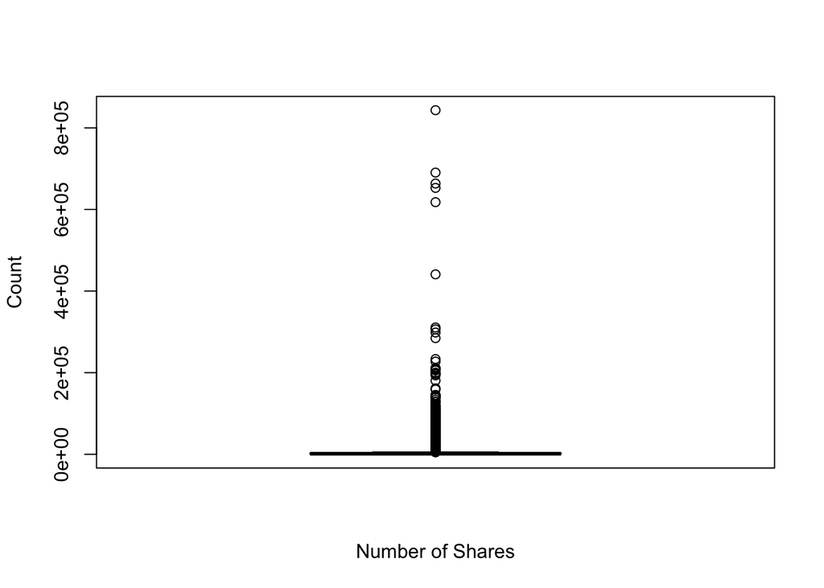

```r
#Number of shares
boxplot(pop_new[c("shares")], xlab = "Number of Shares", ylab = "Count")
```

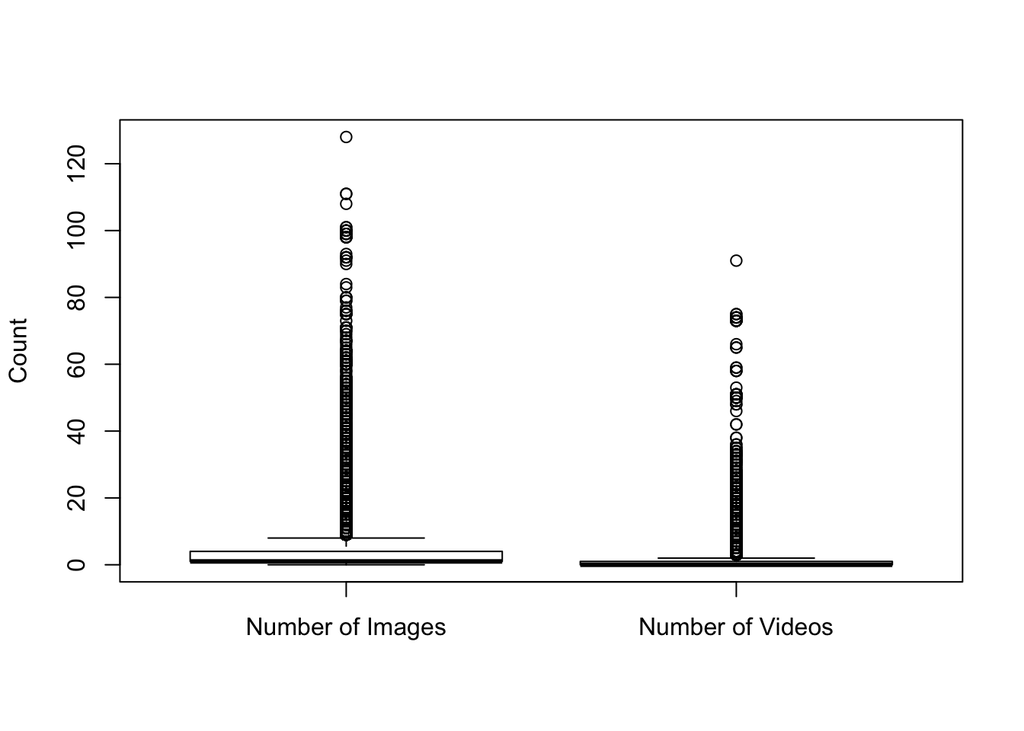

```r
#Number of images and videos
boxplot(pop_new[c("num_imgs", "num_videos")], names = c("Number of Images", "Number of Videos"), ylab = "Count")
```

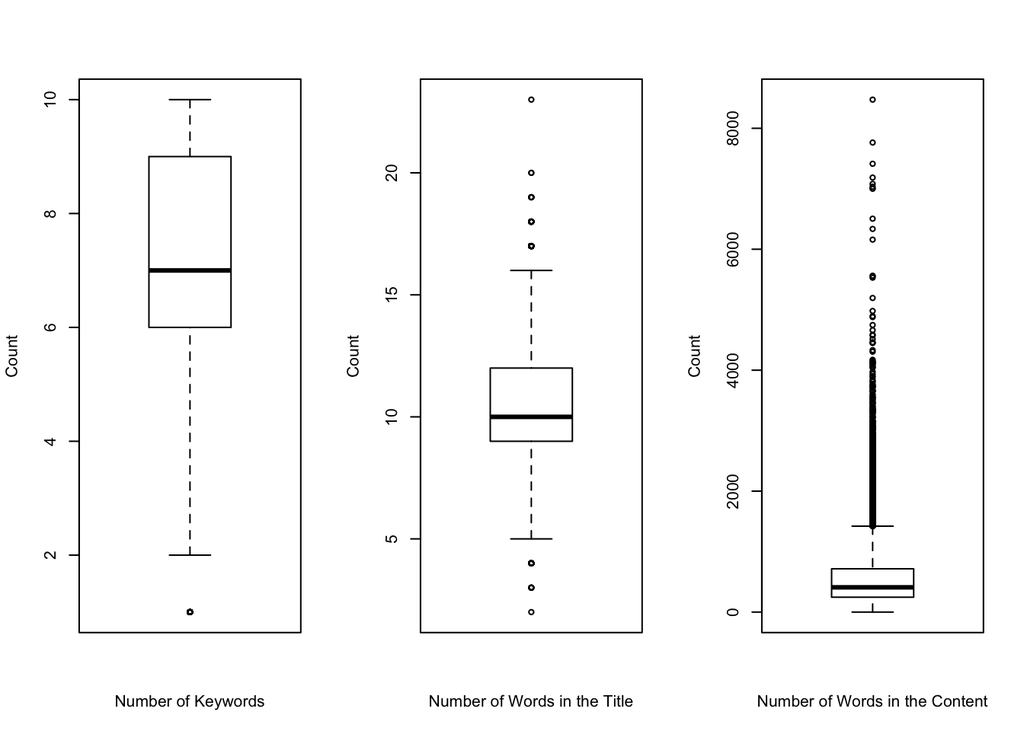

```r
#Number of Keywords; Number of Words in the Title; and Number of Words in the Content
par(mfrow=c(1,3))
boxplot(pop_new$num_keywords, xlab = "Number of Keywords", ylab = "Count")
boxplot(pop_new$n_tokens_title, xlab = "Number of Words in the Title", ylab = "Count")
boxplot(pop_new$n_tokens_content, xlab = "Number of Words in the Content", ylab = "Count")
```

Visualizing the data using boxplots shows that there are outliers present in the data.

Distributions of input and output variables - Histograms

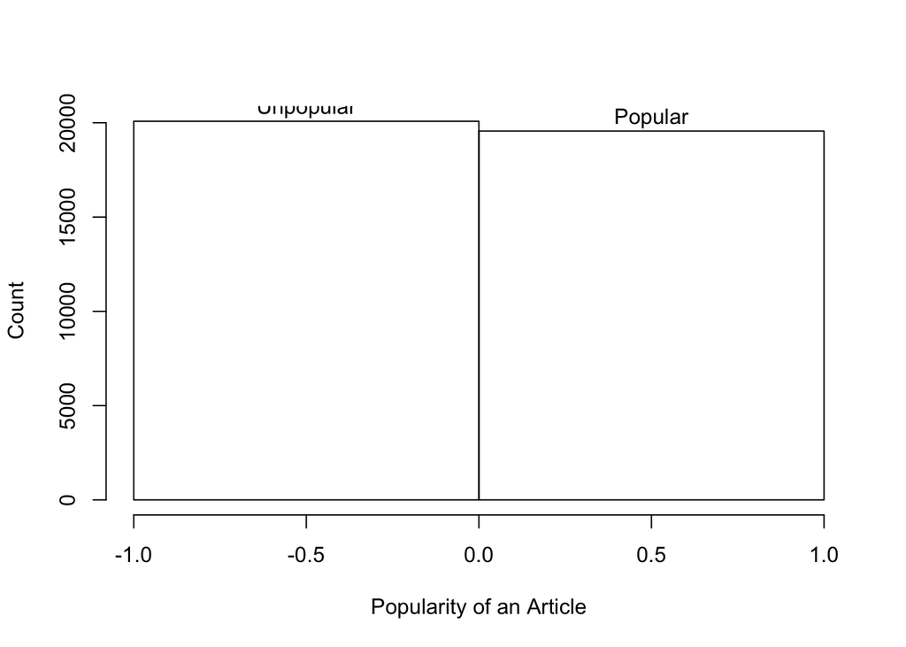

```r
#Popularity of an Article
par(mfrow=c(1,1))
hist(pop_new$shares_cat, xlab = "Popularity of an Article", ylab = "Count", breaks = c(-1,0,1), main = NULL,
     labels = c("Unpopular", "Popular"))
```

The dataset is fairly balanced between unpopular and popular articles.

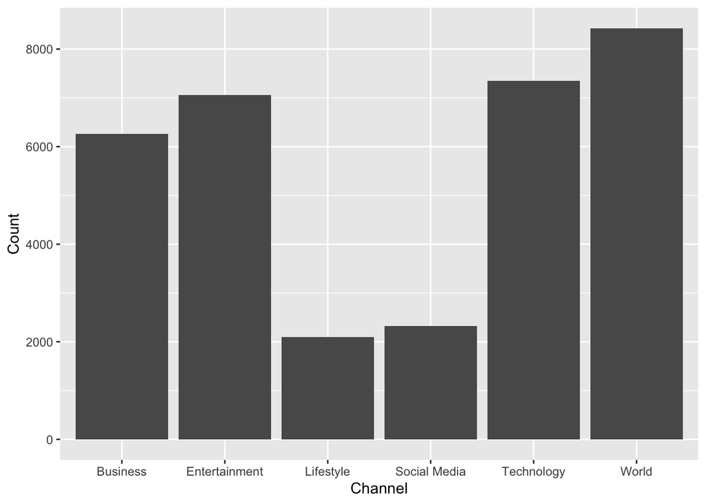

```r
#Type of data channel that the article was published
library(ggplot2)
tab = data.frame(Count=colSums(pop_new[c("data_channel_is_lifestyle", "data_channel_is_entertainment",
                                           "data_channel_is_bus", "data_channel_is_socmed",
                                           "data_channel_is_tech", "data_channel_is_world")]),
                 Channel = names(pop_new[c("data_channel_is_lifestyle", "data_channel_is_entertainment",
                                            "data_channel_is_bus", "data_channel_is_socmed",
                                            "data_channel_is_tech", "data_channel_is_world")]))

ggplot(data = tab, aes(x = Channel, y = Count)) +
  geom_bar(stat = "identity") +
  scale_x_discrete(breaks = c("data_channel_is_lifestyle", "data_channel_is_entertainment",
                              "data_channel_is_bus", "data_channel_is_socmed",
                              "data_channel_is_tech", "data_channel_is_world"),
                   labels = c("Lifestyle", "Entertainment", "Business", "Social Media",
                              "Technology", "World"))
```

Most articles are published to “World” followed by “Technology,” “Entertainment,” “Business,” “Social Media,” and finally “Lifestyle.”

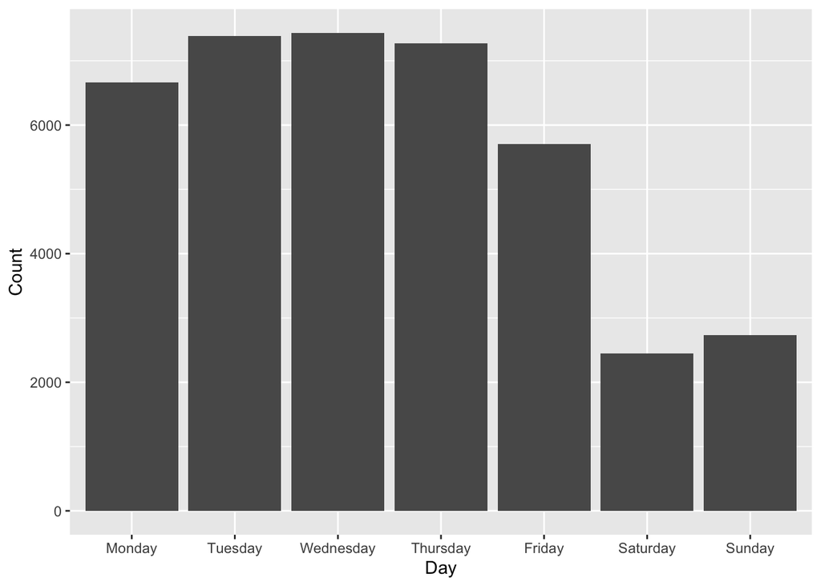

```r
#Day of the Week that the article was published
tab2 = data.frame(Count=colSums(pop_new[c("weekday_is_monday", "weekday_is_tuesday",
                                            "weekday_is_wednesday", "weekday_is_thursday",
                                            "weekday_is_friday", "weekday_is_saturday",
                                            "weekday_is_sunday")]),
                  Day = names(pop_new[c("weekday_is_monday", "weekday_is_tuesday",
                                             "weekday_is_wednesday", "weekday_is_thursday",
                                             "weekday_is_friday", "weekday_is_saturday",
                                             "weekday_is_sunday")]))

tab2$Day <- factor(tab2$Day, levels = c("weekday_is_monday", "weekday_is_tuesday",
                                                "weekday_is_wednesday", "weekday_is_thursday",
                                                "weekday_is_friday", "weekday_is_saturday",
                                                "weekday_is_sunday"))

ggplot(data = tab2, aes(x = Day, y = Count)) +
  geom_bar(stat = "identity") +
  scale_x_discrete(breaks = c("weekday_is_monday", "weekday_is_tuesday",
                              "weekday_is_wednesday", "weekday_is_thursday",
                              "weekday_is_friday", "weekday_is_saturday",
                              "weekday_is_sunday"),
                   labels = c("Monday", "Tuesday", "Wednesday", "Thursday", "Friday",
                              "Saturday", "Sunday"))
```

Most articles are published on Wednesday, followed by Tuesday, Thursday, Monday, Friday, Sunday, and finally Saturday.

Initial Analysis - Bivariate Analysis

Pairwise Visualizations - Scatterplots

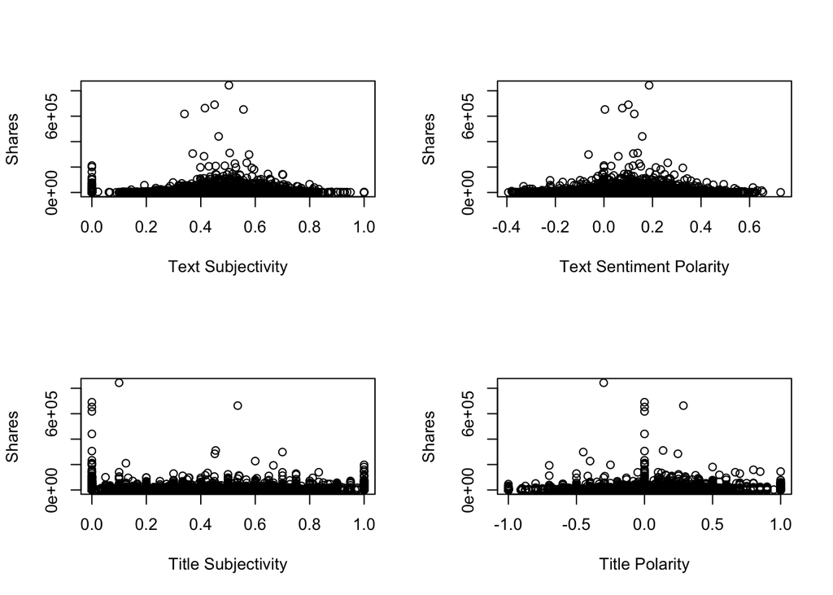

```r
#Scatterplots between Shares and Text Subjectivity, Text Sentiment Polarity, Title Subjectivity, Title Polarity
par(mfrow = c(2,2))
plot(pop_new$global_subjectivity, pop_new$shares, xlab = "Text Subjectivity", ylab = "Shares")
plot(pop_new$global_sentiment_polarity, pop_new$shares, xlab = "Text Sentiment Polarity", ylab = "Shares")
plot(pop_new$title_subjectivity, pop_new$shares, xlab = "Title Subjectivity", ylab = "Shares")
plot(pop_new$title_sentiment_polarity, pop_new$shares, xlab = "Title Polarity", ylab = "Shares")
```

Shares tend to cluster around the center of the distribution suggesting that the most popular articles tend to be more neutral.

```r
#Scatterplot matrix
par(mfrow=c(1,1))
panel.cor <- function(x, y, digits=2, prefix="", cex.cor)
{
  usr <- par("usr"); on.exit(par(usr))
  par(usr = c(0, 1, 0, 1))
  r <- abs(cor(x, y))
  txt <- format(c(r, 0.123456789), digits=digits)[1]
  txt <- paste(prefix, txt, sep="")
  if(missing(cex.cor)) cex <- 0.8/strwidth(txt)

  test <- cor.test(x,y)
  #borrowed from printCoefmat
  Signif <- symnum(test$p.value, corr = FALSE, na = FALSE,
                   cutpoints = c(0, 0.001, 0.01, 0.05, 0.1, 1),
                   symbols = c("***", "**", "*", ".", " "))

  text(0.5, 0.5, txt, cex = cex * r)
  text(.8, .8, Signif, cex=cex, col=2)
}
```

Assign a value of Selected Features that represents the relevant columns of interest between Shares and Text Subjectivity, Text Sentiment Polarity, Title Subjectivity and Title Polarity.

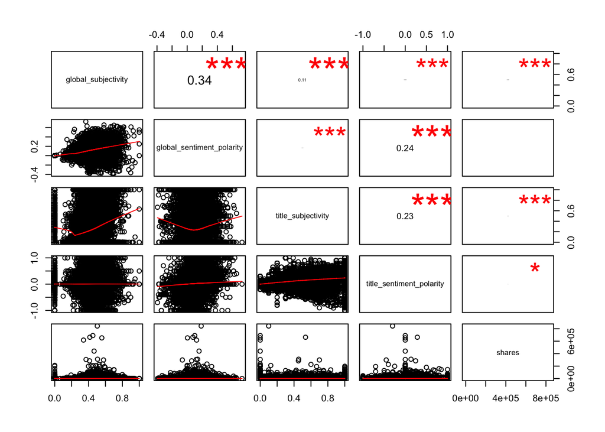

```r
pop_new_Selected_Features <- pop_new[c("global_subjectivity", "global_sentiment_polarity",
                                         "title_subjectivity", "title_sentiment_polarity", "shares")]

#Show the results
pairs(pop_new_Selected_Features, lower.panel=panel.smooth, upper.panel=panel.cor)
```

Low Variance Filter

```r
library(caret)
```

Near-zero variance may be applied to the data to ensure variables are used that help distinguish/determine the popularity of an article.

Create a dataframe with predictor information including whether variables have one unique value, or have very few unique values compared to the number of samples, or whether the ratio of the frequency of the the most common value to the second most common value is large.

```r
nzv <- nearZeroVar(pop_new, saveMetrics= TRUE)
print(nzv)
```

```
##                                freqRatio percentUnique zeroVar   nzv
## n_tokens_title                  1.057184    0.05044900   FALSE FALSE
## n_tokens_content               11.693069    6.06901423   FALSE FALSE
## n_unique_tokens               118.100000   68.81495308   FALSE FALSE
## n_non_stop_words                8.557971    3.66007466   FALSE FALSE
## n_non_stop_unique_tokens       90.846154   57.83977399   FALSE FALSE
## num_hrefs                       1.011367    0.33548582   FALSE FALSE
## num_self_hrefs                  1.123159    0.14882454   FALSE FALSE
## num_imgs                        2.593245    0.22954293   FALSE FALSE
## num_videos                      2.639038    0.13368984   FALSE FALSE
## average_token_length           15.337662   76.01654727   FALSE FALSE
## num_keywords                    1.076606    0.02522450   FALSE FALSE
## data_channel_is_lifestyle      17.887089    0.00504490   FALSE FALSE
## data_channel_is_entertainment   4.617685    0.00504490   FALSE FALSE
## data_channel_is_bus             5.334931    0.00504490   FALSE FALSE
## data_channel_is_socmed         16.065863    0.00504490   FALSE FALSE
## data_channel_is_tech            4.396678    0.00504490   FALSE FALSE
## data_channel_is_world           3.704403    0.00504490   FALSE FALSE
## kw_min_min                      1.929795    0.06558369   FALSE FALSE
## kw_max_min                      1.268519    2.71415599   FALSE FALSE
## kw_avg_min                      8.567901   42.88921400   FALSE FALSE
## kw_min_max                     45.139842    2.57542125   FALSE  TRUE
## kw_max_max                      7.577521    0.08828574   FALSE FALSE
## kw_avg_max                      1.385965   77.77721723   FALSE FALSE
## kw_min_avg                    111.051948   40.31379276   FALSE FALSE
## kw_max_avg                      1.795455   49.03137928   FALSE FALSE
## kw_avg_avg                      9.875000   99.13227727   FALSE FALSE
## self_reference_min_shares       4.154024    3.16567450   FALSE FALSE
## self_reference_max_shares       9.366841    2.86802543   FALSE FALSE
## self_reference_avg_sharess     12.585965   21.75865200   FALSE FALSE
## weekday_is_monday               4.951659    0.00504490   FALSE FALSE
## weekday_is_tuesday              4.364547    0.00504490   FALSE FALSE
## weekday_is_wednesday            4.332078    0.00504490   FALSE FALSE
## weekday_is_thursday             4.455346    0.00504490   FALSE FALSE
## weekday_is_friday               5.953868    0.00504490   FALSE FALSE
## weekday_is_saturday            15.161435    0.00504490   FALSE FALSE
## weekday_is_sunday              13.484472    0.00504490   FALSE FALSE
## is_weekend                      6.638536    0.00504490   FALSE FALSE
## LDA_00                          3.000000   99.22560791   FALSE FALSE
## LDA_01                          1.416667   98.62274241   FALSE FALSE
## LDA_02                          8.500000   99.69982847   FALSE FALSE
## LDA_03                          1.137255   98.28221168   FALSE FALSE
## LDA_04                          2.684211   99.30884875   FALSE FALSE
## global_subjectivity            32.888889   87.02704066   FALSE FALSE
## global_sentiment_polarity      39.900000   87.51639592   FALSE FALSE
## global_rate_positive_words     10.141667   33.19291696   FALSE FALSE
## global_rate_negative_words     29.310345   25.90808193   FALSE FALSE
## rate_positive_words             1.178886    5.76127535   FALSE FALSE
## rate_negative_words             1.585821    5.76127535   FALSE FALSE
## avg_positive_polarity           6.054726   68.86540208   FALSE FALSE
## min_positive_polarity           2.086363    0.08324084   FALSE FALSE
## max_positive_polarity           2.238484    0.09585309   FALSE FALSE
## avg_negative_polarity           5.110220   34.91322773   FALSE FALSE
## min_negative_polarity           1.241491    0.13621229   FALSE FALSE
## max_negative_polarity           1.128019    0.12360004   FALSE FALSE
## title_subjectivity              6.817941    1.69760872   FALSE FALSE
## title_sentiment_polarity        9.428977    2.05075169   FALSE FALSE
## abs_title_subjectivity          7.771093    1.34194330   FALSE FALSE
## abs_title_sentiment_polarity    7.492099    1.64715972   FALSE FALSE
## shares                          1.143707    3.66764201   FALSE FALSE
## shares_cat                      1.026582    0.00504490   FALSE FALSE
```

```r
#Column names of the zero- or near-zero predictors
nzv2 <- nearZeroVar(pop_new, names = TRUE)
print(nzv2)
```

```
## [1] "kw_min_max"
```

```r
#The results indicate one predictor - the minimum shares of the best keyword - has low variance.
```

```r
#Return column index
nzv3 <- nearZeroVar(pop_new)
print(nzv3)
```

```
## [1] 21
```

```r
#Drop column with low variance
filtered_pop <- pop_new[, -nzv3]

#Dimensions of new data frame
dim(filtered_pop)
```

```
## [1] 39644    59
```

Remove the number of shares since the analysis will focus on predicting the popularity of online news articles as a binary classification task.

```r
#Check the column names and remove the shares (integer) column
names(filtered_pop)
```

```
##  [1] "n_tokens_title"                "n_tokens_content"
##  [3] "n_unique_tokens"               "n_non_stop_words"
##  [5] "n_non_stop_unique_tokens"      "num_hrefs"
##  [7] "num_self_hrefs"                "num_imgs"
##  [9] "num_videos"                    "average_token_length"
## [11] "num_keywords"                  "data_channel_is_lifestyle"
## [13] "data_channel_is_entertainment" "data_channel_is_bus"
## [15] "data_channel_is_socmed"        "data_channel_is_tech"
## [17] "data_channel_is_world"         "kw_min_min"
## [19] "kw_max_min"                    "kw_avg_min"
## [21] "kw_max_max"                    "kw_avg_max"
## [23] "kw_min_avg"                    "kw_max_avg"
## [25] "kw_avg_avg"                    "self_reference_min_shares"
## [27] "self_reference_max_shares"     "self_reference_avg_sharess"
## [29] "weekday_is_monday"             "weekday_is_tuesday"
## [31] "weekday_is_wednesday"          "weekday_is_thursday"
## [33] "weekday_is_friday"             "weekday_is_saturday"
## [35] "weekday_is_sunday"             "is_weekend"
## [37] "LDA_00"                        "LDA_01"
## [39] "LDA_02"                        "LDA_03"
## [41] "LDA_04"                        "global_subjectivity"
## [43] "global_sentiment_polarity"     "global_rate_positive_words"
## [45] "global_rate_negative_words"    "rate_positive_words"
## [47] "rate_negative_words"           "avg_positive_polarity"
## [49] "min_positive_polarity"         "max_positive_polarity"
## [51] "avg_negative_polarity"         "min_negative_polarity"
## [53] "max_negative_polarity"         "title_subjectivity"
## [55] "title_sentiment_polarity"      "abs_title_subjectivity"
## [57] "abs_title_sentiment_polarity"  "shares"
## [59] "shares_cat"
```

```r
filtered_pop <- filtered_pop[-58]
```

Correlation Analysis

```r
library(corrplot)
library(MASS)
#Use Spearman correlation coefficient because the data is not normally distributed and has categorical variables
pop_new_cor <- cor(filtered_pop, use = "complete.obs", method = "spearman")
```

Since the dataset has many variables, it may be informative to reduce the size of the correlation matrix.

```r
#Drop duplicate correlations
pop_new_cor[lower.tri(pop_new_cor, diag=TRUE)] <- NA

#Create a table
pop_new_cor <- as.data.frame(as.table(pop_new_cor))

#Remove NA values
pop_new_cor <- na.omit(pop_new_cor)

#Select the correlations that have at least moderate (moderate correlation > 0.4)
pop_new_cor <- subset(pop_new_cor, abs(Freq) > 0.4)

#Sort values by the highest correlation
pop_new_cor <- pop_new_cor[order(-abs(pop_new_cor$Freq)), ]

#Print the table
print(pop_new_cor)
```

```
##                               Var1                         Var2       Freq
## 176               n_tokens_content             n_non_stop_words  0.9949854
## 1593     self_reference_max_shares   self_reference_avg_sharess  0.9731616
## 235                n_unique_tokens     n_non_stop_unique_tokens  0.8813053
## 3302            title_subjectivity abs_title_sentiment_polarity  0.8394189
## 2714           rate_positive_words          rate_negative_words -0.8320259
## 2713    global_rate_negative_words          rate_negative_words  0.8243605
## 1416                    kw_max_avg                   kw_avg_avg  0.8070733
## 1121                    kw_max_min                   kw_avg_min  0.8066579
## 2653     global_sentiment_polarity          rate_positive_words  0.8032534
## 1592     self_reference_min_shares   self_reference_avg_sharess  0.8020695
## 3009         avg_negative_polarity        min_negative_polarity  0.7791302
## 1178                    kw_min_min                   kw_max_max -0.7493595
## 118               n_tokens_content              n_unique_tokens -0.7204282
## 177                n_unique_tokens             n_non_stop_words -0.7111355
```

[output cut: 45 more lines]

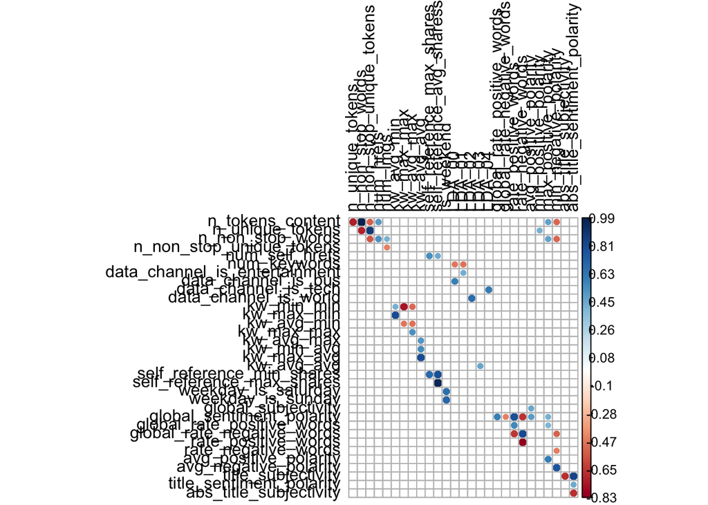

```r
#Transform the table to a matrix to use corrplot
matrix_cor <- reshape2::acast(pop_new_cor, Var1~Var2, value.var="Freq")

#Plot the correlations
corrplot(matrix_cor, method = c("circle"), is.corr = FALSE, tl.col="black", na.label=" ")
```

Remove strongly correlated attributes

```r
library(mlbench)

#Calculate correlation
pop_correlation <- cor(filtered_pop, method = "spearman")

#Find attributes that are highly correlated (greater than 0.7 correlation coefficient) and sort them
correlated <- findCorrelation(pop_correlation, cutoff=0.7)
correlated <- sort(correlated)

#Print the indexes of the highly correlated attributes
print(correlated)
```

```
##  [1]  2  3  4 18 20 25 27 28 36 43 46 47 52 57
```

```r
#Check the names of the correlated data
correlated_pop = filtered_pop[,c(correlated)]
names(correlated_pop)
```

```
##  [1] "n_tokens_content"             "n_unique_tokens"
##  [3] "n_non_stop_words"             "kw_min_min"
##  [5] "kw_avg_min"                   "kw_avg_avg"
##  [7] "self_reference_max_shares"    "self_reference_avg_sharess"
##  [9] "is_weekend"                   "global_sentiment_polarity"
## [11] "rate_positive_words"          "rate_negative_words"
## [13] "min_negative_polarity"        "abs_title_sentiment_polarity"
```

There are 14 variables that may be removed due to being strongly correlated: number of words in the content, rate of unique words in the content, rate of non-stop words in the content, minimum shares of the worst keyword, average shares of the worst keyword, average shares of the average keyword, maximum shares of referenced articles in Mashable, average shares of referenced articles in Mashable, whether the article was published on the weekend, text sentiment polarity, rate of positive words among non-neutral tokens, rate of negative words among non-neutral tokens, minimum polarity of negative words, and absolute polarity level.

```r
#Reduce the data, not including variables that have high correlation
reduced_pop = filtered_pop[,-c(correlated)]

#Check the names of the remaining variables
names(reduced_pop)
```

```
##  [1] "n_tokens_title"                "n_non_stop_unique_tokens"
##  [3] "num_hrefs"                     "num_self_hrefs"
##  [5] "num_imgs"                      "num_videos"
##  [7] "average_token_length"          "num_keywords"
##  [9] "data_channel_is_lifestyle"     "data_channel_is_entertainment"
## [11] "data_channel_is_bus"           "data_channel_is_socmed"
## [13] "data_channel_is_tech"          "data_channel_is_world"
## [15] "kw_max_min"                    "kw_max_max"
## [17] "kw_avg_max"                    "kw_min_avg"
## [19] "kw_max_avg"                    "self_reference_min_shares"
## [21] "weekday_is_monday"             "weekday_is_tuesday"
## [23] "weekday_is_wednesday"          "weekday_is_thursday"
## [25] "weekday_is_friday"             "weekday_is_saturday"
## [27] "weekday_is_sunday"             "LDA_00"
## [29] "LDA_01"                        "LDA_02"
## [31] "LDA_03"                        "LDA_04"
## [33] "global_subjectivity"           "global_rate_positive_words"
## [35] "global_rate_negative_words"    "avg_positive_polarity"
## [37] "min_positive_polarity"         "max_positive_polarity"
## [39] "avg_negative_polarity"         "max_negative_polarity"
## [41] "title_subjectivity"            "title_sentiment_polarity"
## [43] "abs_title_subjectivity"        "shares_cat"
```

```r
#There are 44 remaining variables to be included in the analysis.
```

```r
#Change the categorical variables back to factor to conduct exploratory analysis and dimensionality reduction
reduced_pop$data_channel_is_lifestyle <- as.factor(reduced_pop$data_channel_is_lifestyle)
reduced_pop$data_channel_is_entertainment <- as.factor(reduced_pop$data_channel_is_entertainment)
reduced_pop$data_channel_is_bus <- as.factor(reduced_pop$data_channel_is_bus)
reduced_pop$data_channel_is_socmed <- as.factor(reduced_pop$data_channel_is_socmed)
reduced_pop$data_channel_is_tech <- as.factor(reduced_pop$data_channel_is_tech)
reduced_pop$data_channel_is_world <- as.factor(reduced_pop$data_channel_is_world)
reduced_pop$weekday_is_monday <- as.factor(reduced_pop$weekday_is_monday)
reduced_pop$weekday_is_tuesday <- as.factor(reduced_pop$weekday_is_tuesday)
reduced_pop$weekday_is_wednesday <- as.factor(reduced_pop$weekday_is_wednesday)
reduced_pop$weekday_is_thursday <- as.factor(reduced_pop$weekday_is_thursday)
reduced_pop$weekday_is_friday <- as.factor(reduced_pop$weekday_is_friday)
reduced_pop$weekday_is_saturday <- as.factor(reduced_pop$weekday_is_saturday)
reduced_pop$weekday_is_sunday <- as.factor(reduced_pop$weekday_is_sunday)
reduced_pop$shares_cat <- as.factor(reduced_pop$shares_cat)
```

```r
#Save the dataframe
write.csv(reduced_pop, "reduced_pop.csv")
```